# Exercise - EDA

This is the first exercise from Doing Data Science by Cathy O’Neil and Rachel Schutt. The goal of this exercise is to do exploratory data analysis on data from the New York Times

#### Load libraries

```r
library(dplyr)
library(ggplot2)
library(gridExtra)
library(scales)
```

#### Create function to get data

This function takes in a day (1 - 31) and a type of data grab (“combined” which combines all days or NULL which just gets one day)

```r
getData <- function(day, type = ""){

  url_stub <- "http://stat.columbia.edu/~rachel/datasets/nyt"

  if (type != "combined" | day == 1) {
    initial_data <- read.csv(url(paste0(url_stub, day, ".csv"))) %>% mutate(day = as.numeric(day))
    return(initial_data)
  } else if (day > 1 & day <= 31) {
    initial_data <- read.csv(url(paste0(url_stub, "1.csv"))) %>% mutate(day = 1)

    for (i in 2:day) {
      url_full <- paste0(url_stub, i, ".csv")
      new_data <- assign(paste0("data", i), read.csv(url(url_full)))
      new_data <- mutate(new_data, day = as.numeric(i))
      initial_data <- union(initial_data, new_data)
    }

    return(initial_data)
  } else {
    return(paste("Bad input"))
  }
}
```

#### Get the data for one day

```r
df <- getData(1, type = "combined")
```

### 1. Create a new variable, age_group, that categorizes users as “<18”, “18-24”, “25-34”, “35-44”, “45-54”, “55-64”, “65+”

```r
# Function to label data with age groups, gender labels, and signed in labels.
# Function takes a data frame and returns a data frame.
labelData <- function(df) {
  df$age_group <- cut(df$Age, c(-Inf, 18, 24, 34, 44, 54, 64, Inf),
                      labels = c("<18", "18-24", "25-34", "35-44", "45-54", "55-64", "65+"))
  df$Gender <- factor(df$Gender, labels = c("Female", "Male"))
  df$Signed_In <- factor(df$Signed_In, levels = c(0, 1), labels = c("Y", "N"))

  return(df)
}

# Label the data.
df <- labelData(df)
```

### 2. For a single day:

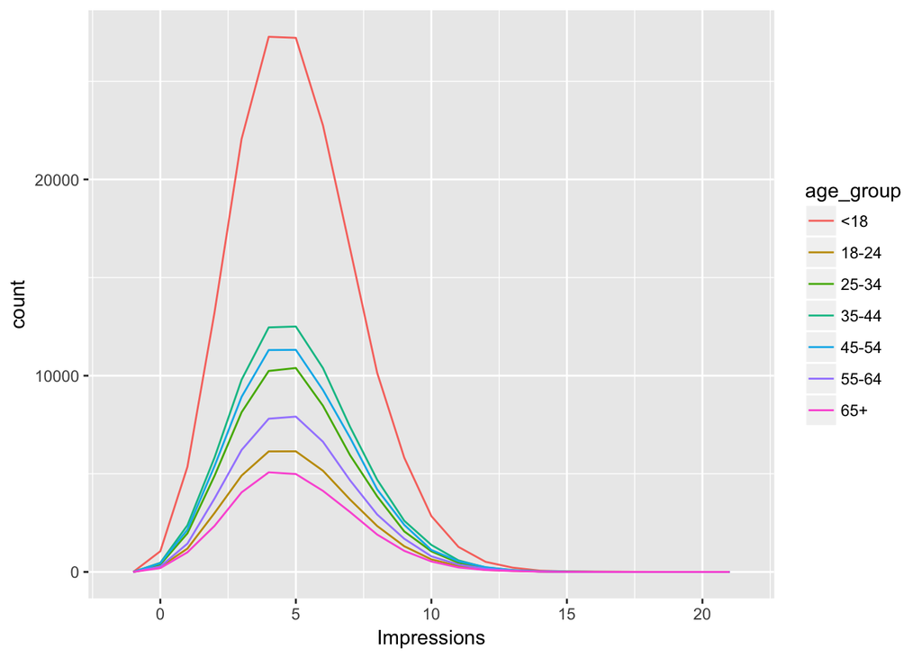

```r
# Plot of impressions by age group.
ggplot(df, aes(Impressions, colour = age_group)) +
  geom_freqpoly(binwidth = 1)
```

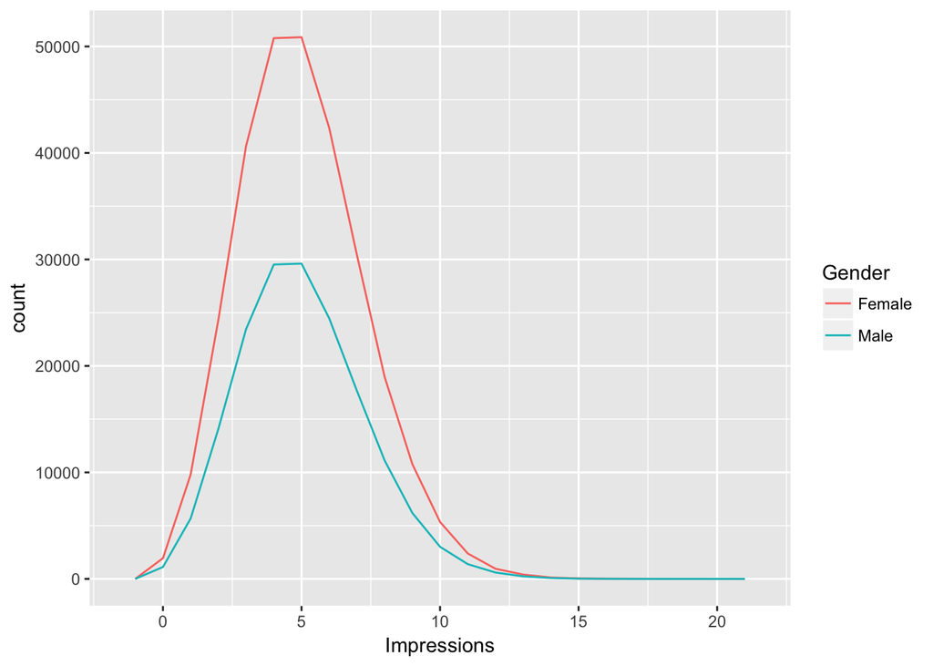

```r
# Plot of impressions by gender
ggplot(df, aes(Impressions, color = Gender)) +
  geom_freqpoly(binwidth = 1)
```

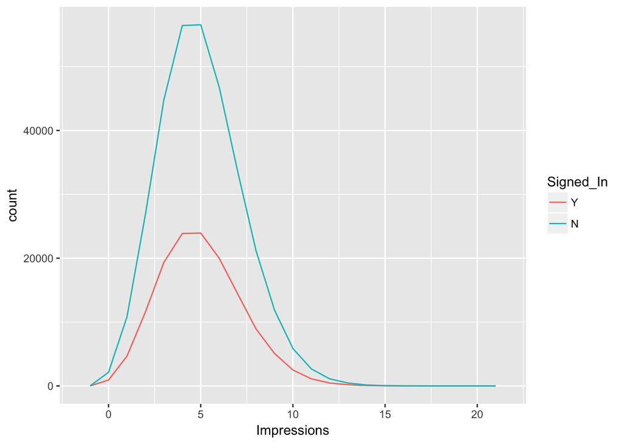

```r
# Plot of impressions by signed in status
ggplot(df, aes(Impressions, colour = Signed_In)) +
  geom_freqpoly(binwidth = 1)
```

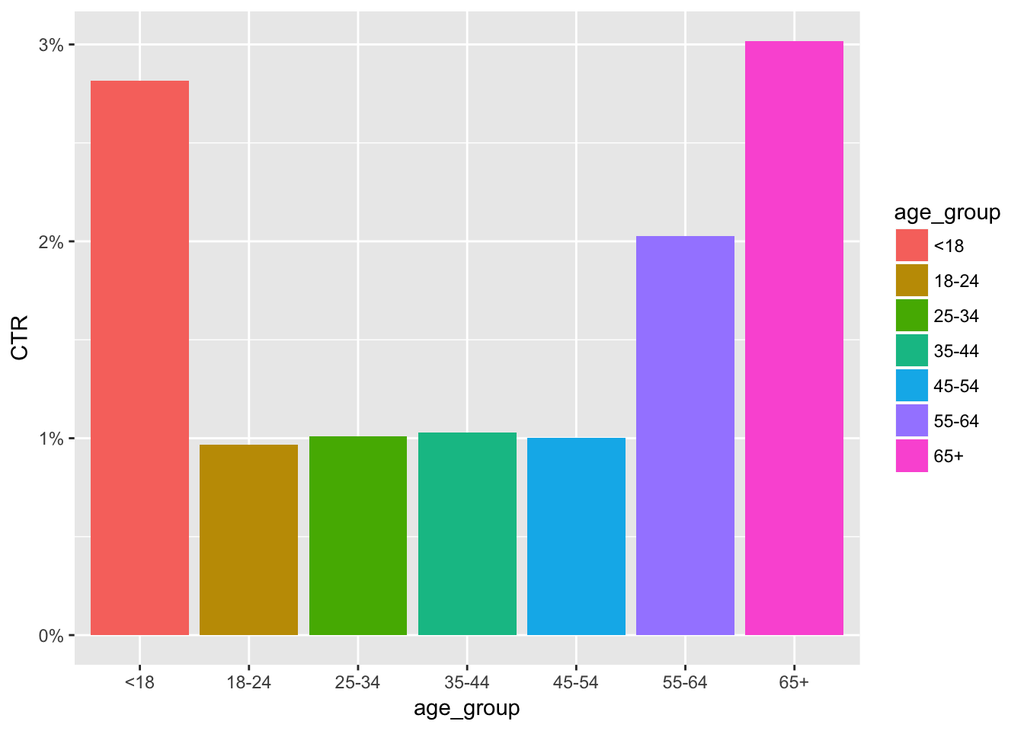

```r
# Plot of CTR by age group.
df %>%
  group_by(age_group) %>%
  summarize(CTR = sum(Clicks) / sum(Impressions)) %>%
  filter(is.na(CTR) == FALSE) %>%
  ggplot(aes(age_group, CTR, fill = age_group)) +
    geom_bar(stat = 'identity') +
    scale_y_continuous(labels = percent)
```

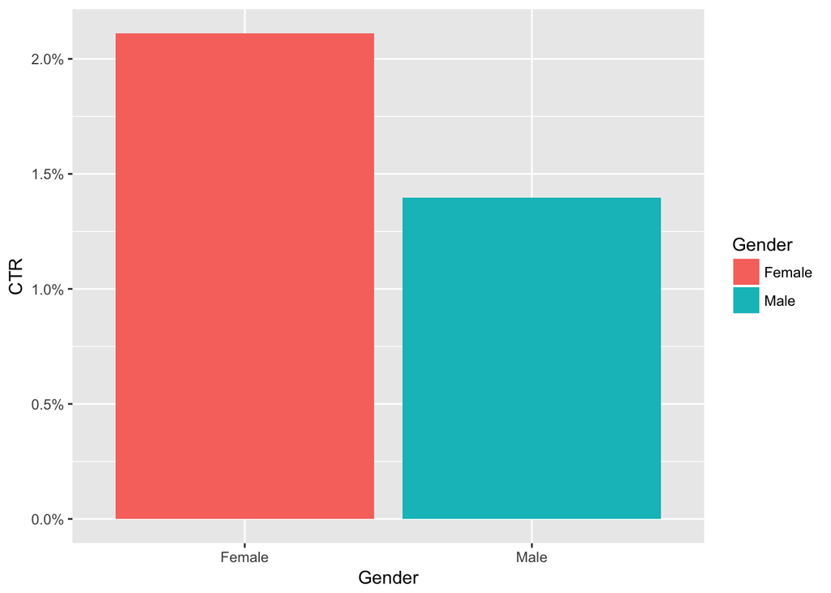

```r
# Plot of CTR by gender.
df %>%
  group_by(Gender) %>%
  summarize(CTR = sum(Clicks) / sum(Impressions)) %>%
  filter(is.na(CTR) == FALSE) %>%
  ggplot(aes(Gender, CTR, fill = Gender)) +
  geom_bar(stat = 'identity') +
  scale_y_continuous(labels = percent)
```

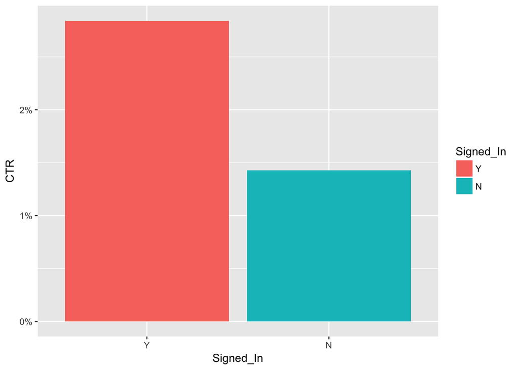

```r
# Plot of CTR by signed in status
df %>%
  group_by(Signed_In) %>%
  summarize(CTR = sum(Clicks) / sum(Impressions)) %>%
  filter(is.na(CTR) == FALSE) %>%
  ggplot(aes(Signed_In, CTR, fill = Signed_In)) +
  geom_bar(stat = 'identity') +
  scale_y_continuous(labels = percent)
```

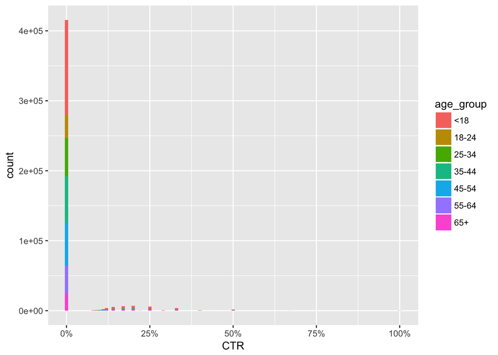

```r
# Most common CTR values
df %>%
  mutate(CTR = round(Clicks/Impressions, 2)) %>%
  filter(is.na(CTR) == FALSE) %>%
  ggplot(aes(CTR, fill = age_group)) +
  geom_histogram(binwidth = 0.01) +
  scale_x_continuous(labels = percent)
```

##### Define a new variable to segment or categorize users based on their click behavior

```r
# Function to create variable "engaged" for users with CTR > 2%; removing users w/ clicks and no impressions.
# Function takes a data frame and returns a data frame with a new variable for "engagement".
createEngageVariable <- function(df) {
    df <- df %>%
      mutate(CTR = round(Clicks/Impressions, 2)) %>%
      mutate(engaged = if_else(CTR > 0.02, "Y", "N")) %>%
      filter(is.na(CTR) == FALSE)
    return(df)
}

df <- createEngageVariable(df)
```

##### Explore the data and make visual and quantitative comparisons across user segments/demographics

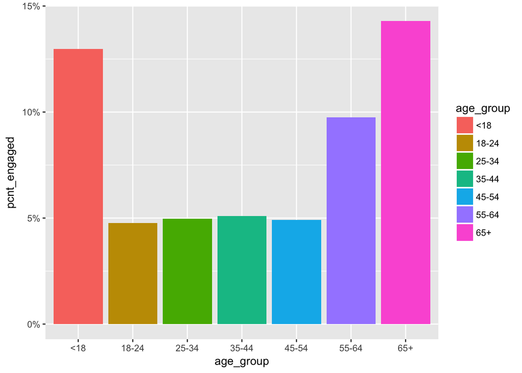

```r
# Plot "engaged" users by age group.
df %>%
  group_by(age_group, engaged) %>%
  summarize(cnt_engaged = n()) %>%
  mutate(pcnt_engaged = cnt_engaged / sum(cnt_engaged)) %>%
  filter(engaged == "Y") %>%
  ggplot(aes(age_group, pcnt_engaged, fill = age_group)) +
    geom_bar(stat = 'identity') +
    scale_y_continuous(labels = percent)
```

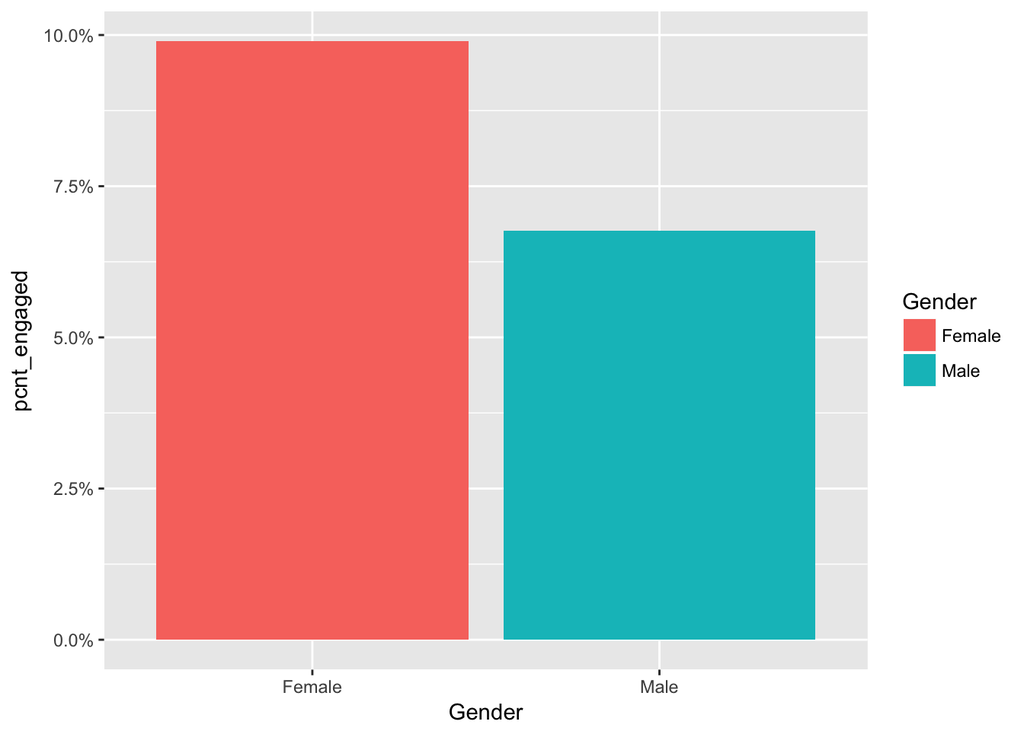

```r
# Plot "engaged" users by gender.
df %>%
  group_by(Gender, engaged) %>%
  summarize(cnt_engaged = n()) %>%
  mutate(pcnt_engaged = cnt_engaged / sum(cnt_engaged)) %>%
  filter(engaged == "Y") %>%
  ggplot(aes(Gender, pcnt_engaged, fill = Gender)) +
    geom_bar(stat = 'identity') +
    scale_y_continuous(labels = percent)
```

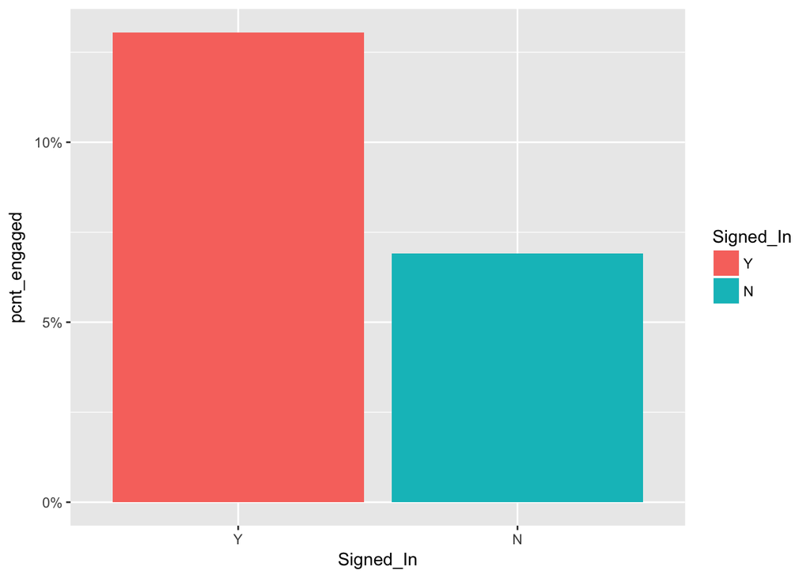

```r
# Plot "engaged" users by signed in status.
df %>%
  group_by(Signed_In, engaged) %>%
  summarize(cnt_engaged = n()) %>%
  mutate(pcnt_engaged = cnt_engaged / sum(cnt_engaged)) %>%
  filter(engaged == "Y") %>%
  ggplot(aes(Signed_In, pcnt_engaged, fill = Signed_In)) +
    geom_bar(stat = 'identity') +
    scale_y_continuous(labels = percent)
```

##### Create metrics/measurements/statistics that summarize the data

```r
# Overall summary.
summary(df)
```

```
##       Age            Gender        Impressions         Clicks
##  Min.   :  0.00   Female:288229   Min.   : 1.000   Min.   :0.00000
##  1st Qu.:  0.00   Male  :167146   1st Qu.: 3.000   1st Qu.:0.00000
##  Median : 31.00                   Median : 5.000   Median :0.00000
##  Mean   : 29.48                   Mean   : 5.041   Mean   :0.09322
##  3rd Qu.: 48.00                   3rd Qu.: 6.000   3rd Qu.:0.00000
##  Max.   :108.00                   Max.   :20.000   Max.   :4.00000
##
##  Signed_In       day    age_group           CTR
##  Y:136177   Min.   :1   <18  :155303   Min.   :0.00000
##  N:319198   1st Qu.:1   18-24: 35014   1st Qu.:0.00000
##             Median :1   25-34: 57801   Median :0.00000
##             Mean   :1   35-44: 70394   Mean   :0.01841
##             3rd Qu.:1   45-54: 63845   3rd Qu.:0.00000
##             Max.   :1   55-64: 44462   Max.   :1.00000
##                         65+  : 28556
##    engaged
##  Length:455375
##  Class :character
##  Mode  :character
##
##
##
##
```

```r
# Gender breakdown.
pcnt_female <- (group_by(df, Gender) %>%
                  summarise(count = n()) %>%
                  mutate(pcnt = count/ sum(count)) %>%
                  filter(Gender == "Female")
                )$pcnt
pcnt_male <- (group_by(df, Gender) %>%
                summarise(count = n()) %>%
                mutate(pcnt = count/ sum(count)) %>%
                filter(Gender == "Male")
              )$pcnt
paste0("Percent Female: ", round(100*pcnt_female, 2), '%')
```

```
## [1] "Percent Female: 63.29%"
```

```r
paste0("Percent Male: ", round(100*pcnt_male, 2), '%')
```

```
## [1] "Percent Male: 36.71%"
```

```r
# Signed In breakdown.
pcnt_signed_in <- (group_by(df, Signed_In) %>%
                     summarise(count = n()) %>%
                     mutate(pcnt = count/ sum(count)) %>%
                     filter(Signed_In == "Y")
                   )$pcnt

pcnt_signed_out <- (group_by(df, Signed_In) %>%
                      summarise(count = n()) %>%
                      mutate(pcnt = count/ sum(count)) %>%
                      filter(Signed_In == "N")
                    )$pcnt
paste0("Percent Signed In: ", round(100*pcnt_signed_in, 2), '%')
```

```
## [1] "Percent Signed In: 29.9%"
```

```r
paste0("Percent Signed Out: ", round(100*pcnt_signed_out, 2), '%')
```

```
## [1] "Percent Signed Out: 70.1%"
```

### 3. Extend the analysis across days. Visualize some metrics and distributions over time.

```r
df_all <- getData(31, type = "combined")
df_all <- labelData(df_all)
df_all <- createEngageVariable(df_all)
```

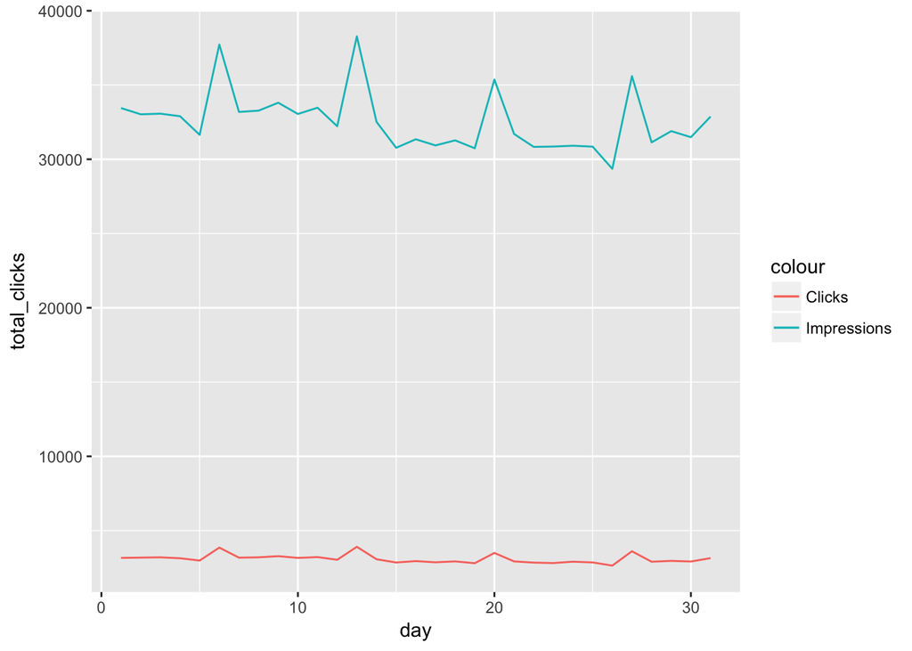

```r
# Plot clicks and impressions over time
df_all %>%
  group_by(day) %>% summarise(total_impressions = sum(Impressions), total_clicks = sum(Clicks)) %>%
  ggplot(aes(x = day)) +
    geom_line(aes(y = total_clicks, color = "Clicks")) +
    geom_line(aes(y = total_impressions, color = "Impressions"))
```

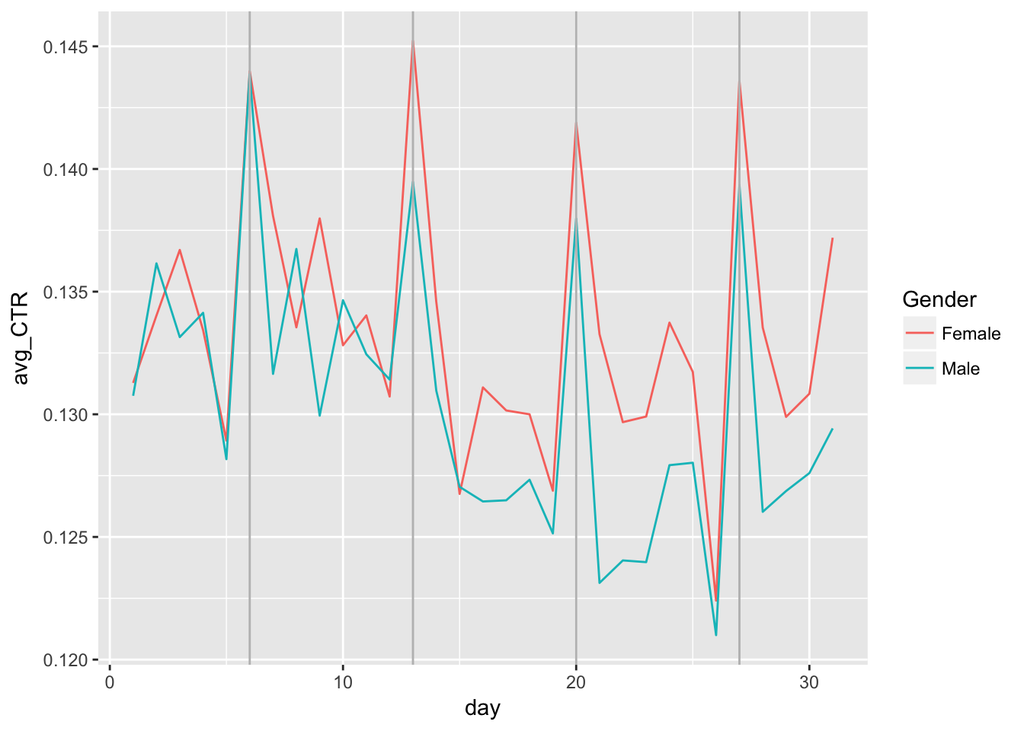

```r
# Plot avg CTR by gender over time
df_all %>%
  group_by(day, Gender) %>% summarize(avg_CTR = mean(CTR)) %>%
  ggplot(aes(x = day, y = avg_CTR, color = Gender)) +
    geom_line() +
    geom_vline(xintercept = c(6, 13, 20, 27), color = "grey")
```

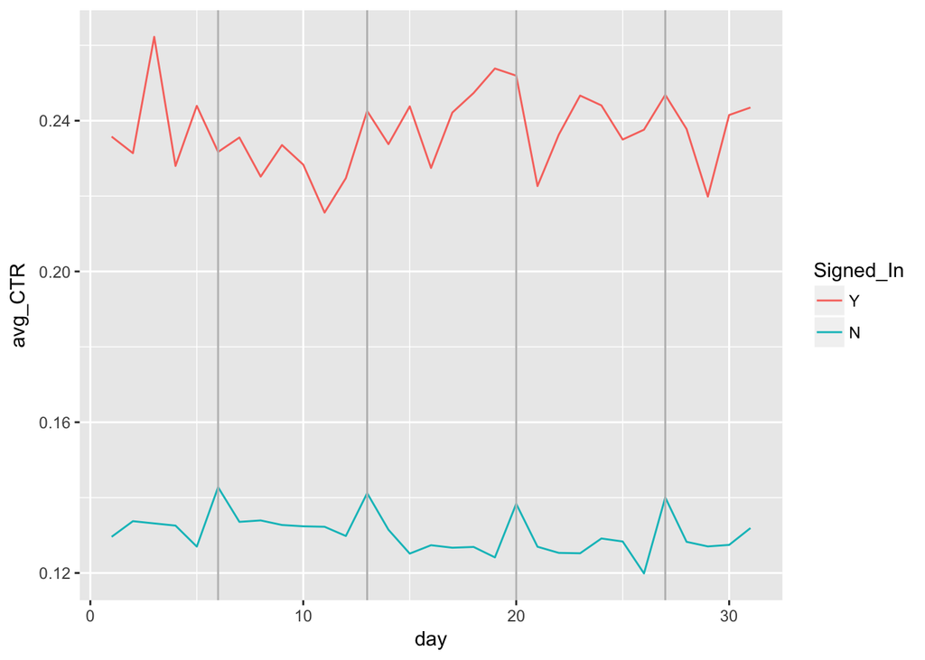

```r
# Plot avg CTR by signed in stauts over time
df_all %>%
  group_by(day, Signed_In) %>% summarize(avg_CTR = mean(CTR)) %>%
  ggplot(aes(x = day, y = avg_CTR, color = Signed_In)) +
  geom_line() +
  geom_vline(xintercept = c(6, 13, 20, 27), color = "grey")
```

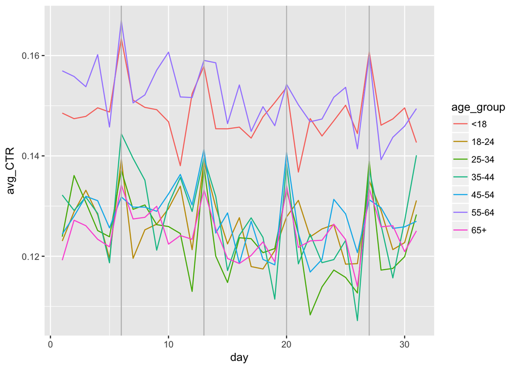

```r
# Plot avg CTR by age group over time
df_all %>%
  group_by(day, age_group) %>% summarize(avg_CTR = mean(CTR)) %>%
  ggplot(aes(x = day, y = avg_CTR, color = age_group)) +
    geom_line() +
    geom_vline(xintercept = c(6, 13, 20, 27), color = "grey")
```

### 4. Describe and interpret any patterns you find

Some general paterns:

- The young (< 18) and the elderly (> 55) are more engaged
- Engagment has a weekly trend, spiking on the 6th day of the month and then every week later. Maybe this is a spike on the weekend? Would have to know more about the month in which the data was captured.
- Signed in users are more like to engage with content *Women are more likelt to engage with content